# First, I am going to read the largest files (Master, Batting, Pitching, Fielding) and explore them a bit to understand the data at hand. I also read through the ReadME file to understand all the stats

# OBP

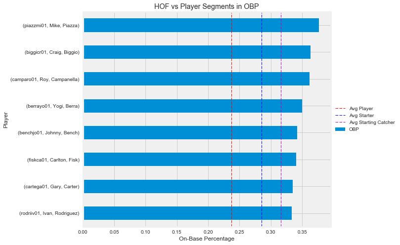

```python
%matplotlib inline

playerID_od_c = playerID_od_c.sort(['OBP'])

fig, ax = plt.subplots(figsize =(10,8))

playerID_od_c.plot(kind='barh', y=['OBP'], ax=ax)

ax.set(title='HOF vs Player Segments in OBP', xlabel = 'On-Base Percentage', ylabel = 'Player')

ax.axvline(x = batting_groupID['OBP'].mean(), color='r', label='Avg Player', linestyle='--', linewidth=1)

ax.axvline(x = batting_starters['OBP'].mean(), color='b', label='Avg Starter', linestyle='--', linewidth=1)

ax.axvline(x = batting_starter_catchers['OBP'].mean(), color='m', label='Avg Starting Catcher', linestyle='--', linewidth=1)

box = ax.get_position()
ax.set_position([box.x0, box.y0, box.width * 0.8, box.height])
plt.legend(loc='center left', bbox_to_anchor=(1, 0.5))
```

# SLG

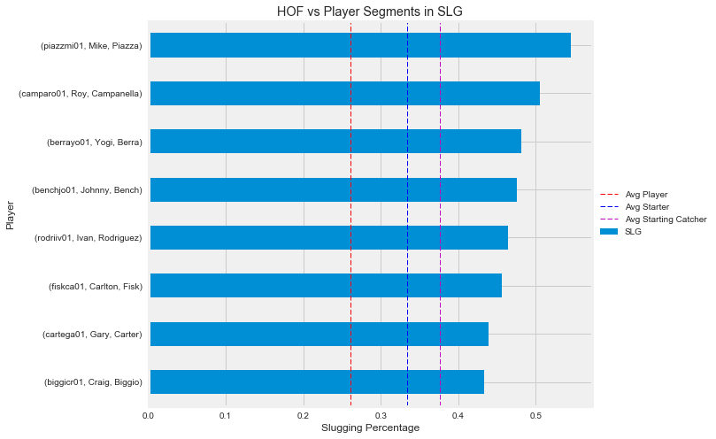

```python
%matplotlib inline

playerID_od_c = playerID_od_c.sort(['SLG'])

fig, ax = plt.subplots(figsize =(10,8))

playerID_od_c.plot(kind='barh', y=['SLG'], ax=ax)

ax.set(title='HOF vs Player Segments in SLG', xlabel = 'Slugging Percentage', ylabel = 'Player')

ax.axvline(x = batting_groupID['SLG'].mean(), color='r', label='Avg Player', linestyle='--', linewidth=1)

ax.axvline(x = batting_starters['SLG'].mean(), color='b', label='Avg Starter', linestyle='--', linewidth=1)

ax.axvline(x = batting_starter_catchers['SLG'].mean(), color='m', label='Avg Starting Catcher', linestyle='--', linewidth=1)

box = ax.get_position()
ax.set_position([box.x0, box.y0, box.width * 0.8, box.height])
plt.legend(loc='center left', bbox_to_anchor=(1, 0.5))
```

# OPS

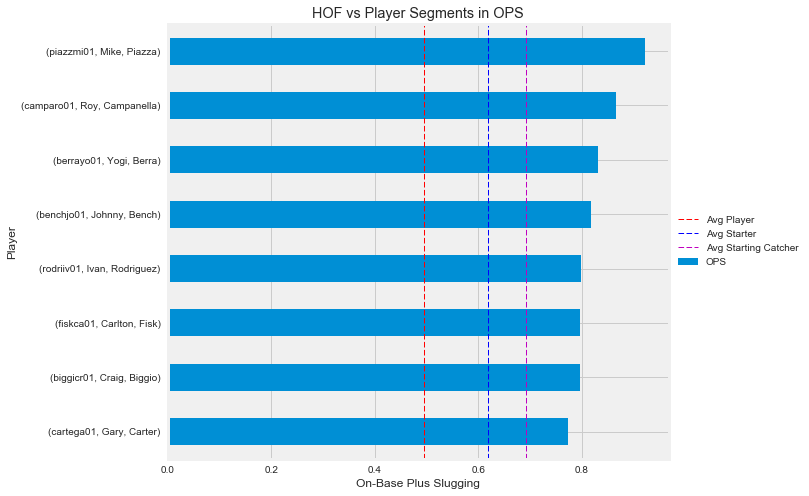

```python
%matplotlib inline

playerID_od_c = playerID_od_c.sort(['OPS'])

fig, ax = plt.subplots(figsize =(10,8))

playerID_od_c.plot(kind='barh', y=['OPS'], ax=ax)

ax.set(title='HOF vs Player Segments in OPS', xlabel = 'On-Base Plus Slugging', ylabel = 'Player')

ax.axvline(x = batting_groupID['OPS'].mean(), color='r', label='Avg Player', linestyle='--', linewidth=1)

ax.axvline(x = batting_starters['OPS'].mean(), color='b', label='Avg Starter', linestyle='--', linewidth=1)

ax.axvline(x = batting_starter_catchers['OPS'].mean(), color='m', label='Avg Starting Catcher', linestyle='--', linewidth=1)

box = ax.get_position()
ax.set_position([box.x0, box.y0, box.width * 0.8, box.height])
plt.legend(loc='center left', bbox_to_anchor=(1, 0.5))
```

# How do the HOF players compare to everyone else? Are there any other outstanding catchers not included in the Hall of Fame? Who were they?

```python
# Setting Roy Campanella's In_HOF value higher because groupby
# counts the number of True/False's to assign a numerical value
# for the column 'In_HOF'. This will color Campanella's data
# points as strongly as other HOFers.

# Roy Camapanella had a shorter career making his count of 'In_HOF'
# Trues substantially less than the other HOFers, which made his
# colored point lighter than the other HOFers.

# Roy Campanella's career was actually stopped short because of a
# car accident he was a part of leaving him unable to play baseball
# in the middle of his career. Nonetheless, his outstanding
# production still allowed him to make the Hall of Fame.

batting_starter_catchers = batting_starter_catchers.set_value('camparo01', 'In_HOF', 20)
```

## Creation of matplotlib graph to compare Hall of Famers to all other Players in various statistics

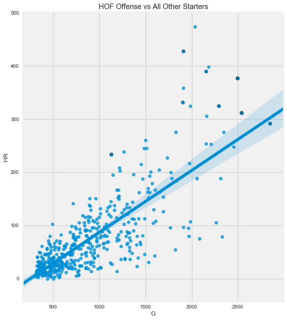

```python
from matplotlib import cm, colors

# Scatter Plot
fig, ax = plt.subplots(figsize =(10,10))
plt.subplots_adjust(bottom=0.1, right=0.8, top=0.9)
ax.set(title='HOF Offense vs All Other Starters', xlabel = 'At Bats', ylabel = 'Home Runs')

colors = batting_starter_catchers['In_HOF']

points = ax.scatter(batting_starter_catchers['G'], batting_starter_catchers['HR'], \
                    c = colors)

#Regression line for Games & HRs
sns.regplot(data=batting_starter_catchers, x="G", y="HR", ax=ax)
```

## To use the library mpld3 for plotting, you must use Python 3.4 Because of this, I created and changed environments & kernels for this notebook to Python 3.4

```python
# import os
# os.getcwd()

# import sys
# sys.executable
```

## Making scatter plots interactive to find out what other players compare to the current Hall of Famers offensive numbers.

```python
import mpld3

labels = batting_starter_catchers.index.tolist()
tooltip = mpld3.plugins.PointLabelTooltip(points, labels, hoffset = 70, voffset = 50)
mpld3.plugins.connect(fig, tooltip)
mpld3.display(fig)
```

[output not shown]